# Appendix, Michał Szumielewicz

|  | total_day_minutes | total_day_charge | total_eve_minutes | total_eve_charge | total_night_minutes | total_night_charge | total_intl_minutes | total_intl_charge |
| --- | --- | --- | --- | --- | --- | --- | --- | --- |
| 0 | 265.1 | 45.07 | 197.4 | 16.78 | 244.7 | 11.01 | 10.0 | 2.70 |
| 1 | 161.6 | 27.47 | 195.5 | 16.62 | 254.4 | 11.45 | 13.7 | 3.70 |
| 2 | 243.4 | 41.38 | 121.2 | 10.30 | 162.6 | 7.32 | 12.2 | 3.29 |
| 3 | 299.4 | 50.90 | 61.9 | 5.26 | 196.9 | 8.86 | 6.6 | 1.78 |
| 4 | 166.7 | 28.34 | 148.3 | 12.61 | 186.9 | 8.41 | 10.1 | 2.73 |
| ... | ... | ... | ... | ... | ... | ... | ... | ... |
| 4995 | 235.7 | 40.07 | 223.0 | 18.96 | 297.5 | 13.39 | 9.9 | 2.67 |
| 4996 | 184.2 | 31.31 | 256.8 | 21.83 | 213.6 | 9.61 | 14.7 | 3.97 |
| 4997 | 140.6 | 23.90 | 172.8 | 14.69 | 212.4 | 9.56 | 13.6 | 3.67 |
| 4998 | 188.8 | 32.10 | 171.7 | 14.59 | 224.4 | 10.10 | 8.5 | 2.30 |
| 4999 | 129.4 | 22.00 | 267.1 | 22.70 | 154.8 | 6.97 | 9.3 | 2.51 |

5000 rows × 8 columns

I use the churn dataset with 5000 rows of 8 features and a target class.

# Compare LIME for various observations in the dataset. How stable are these explanations?

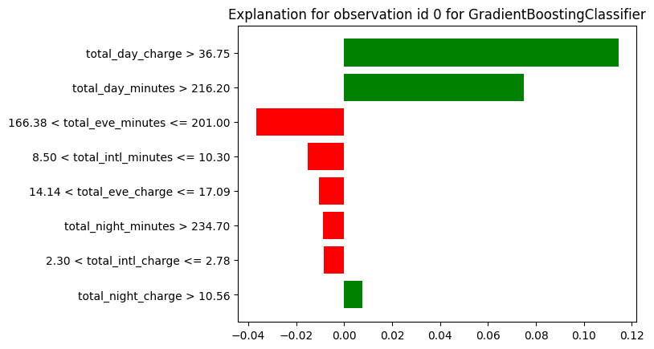

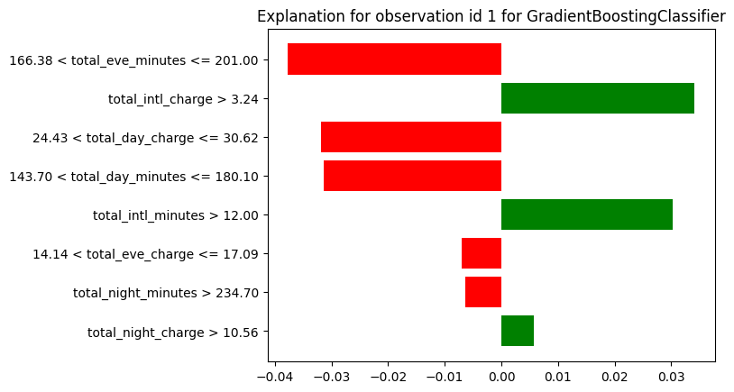

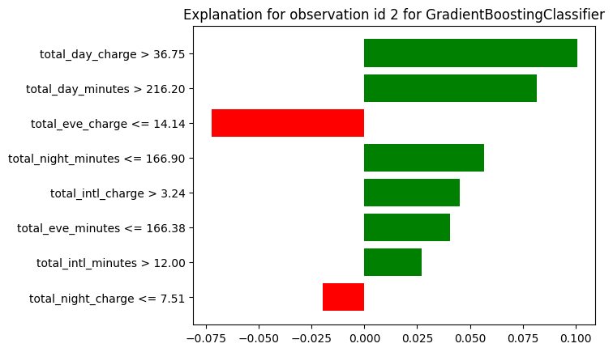

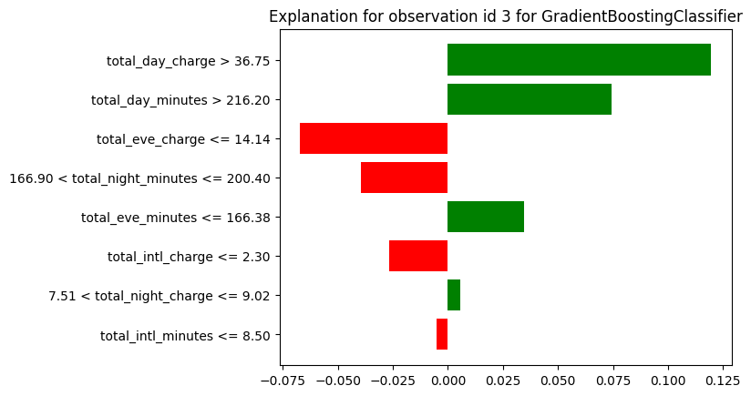

The class probability values in the explanations based on the same conditions differ across various observations although they still tend to be similar, especially those with the greatest absolute values in the explanations. The ones less important can have big differences in terms of relative value.

# Compare LIME with the explanations obtained using SHAP. What are the main differences between them?

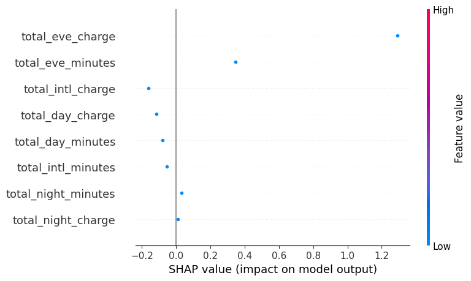

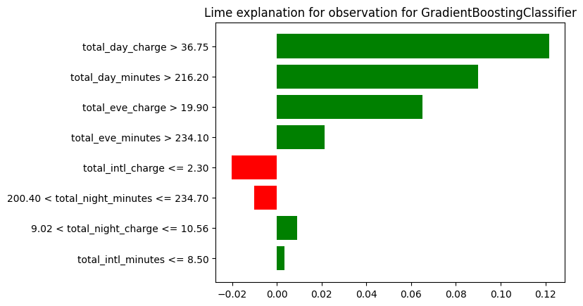

SHAP can sometimes have vastly different explanations than LIME. The seemingly most important factor for the class (if the customer churned) according to LIME is a factor slightly against the class according to SHAP.

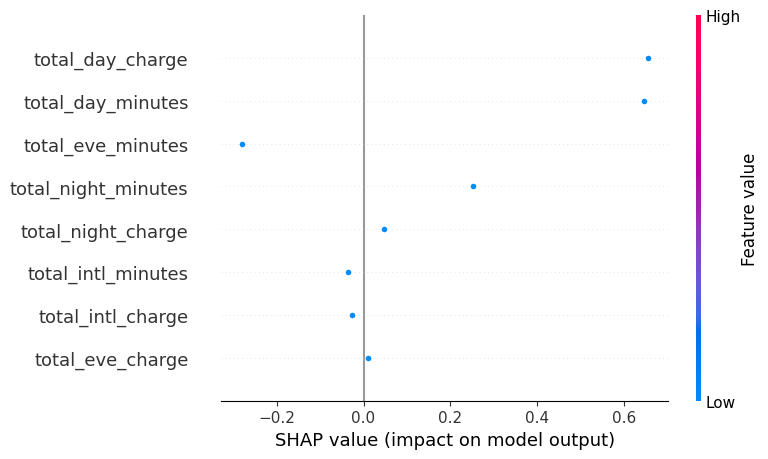

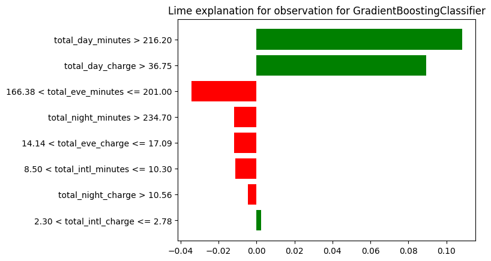

They can however explain things very similarly in other cases (except the total_night_minutes one)

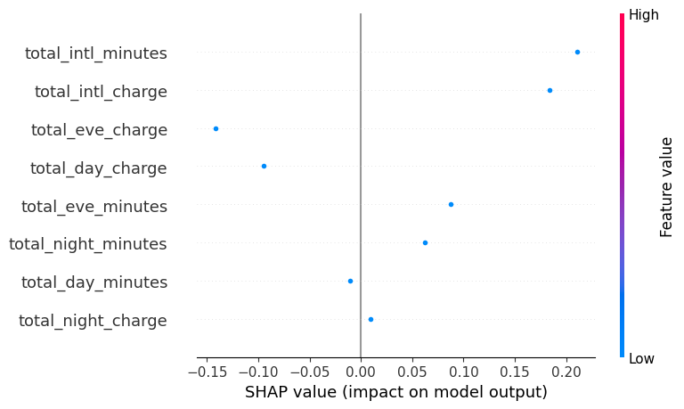

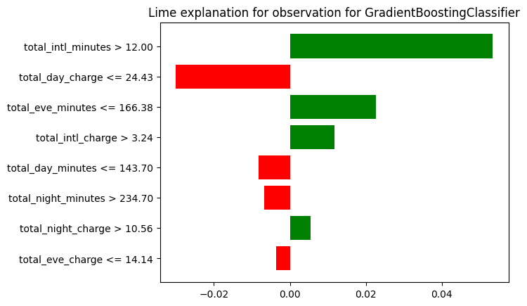

The main differences between LIME and SHAP explanations seem to be mainly in terms of values of the different factors while they generally agree on the "direction" of the impact.

# Compare LIME between at least two different models. Are there any systematic differences across many observations?

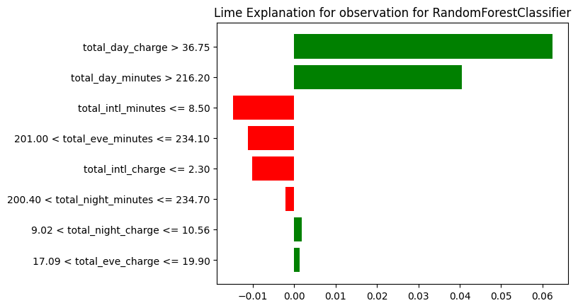

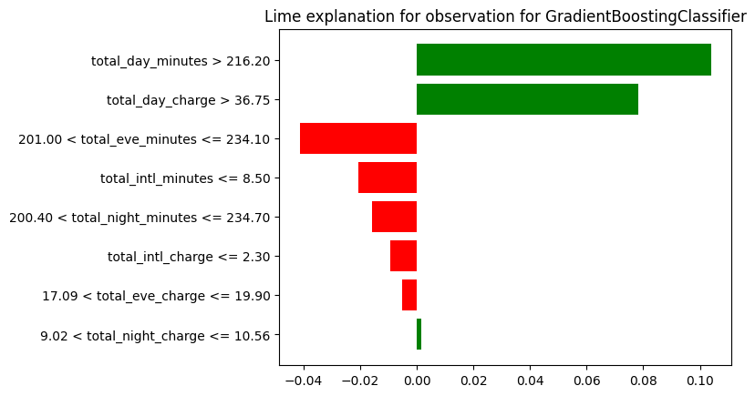

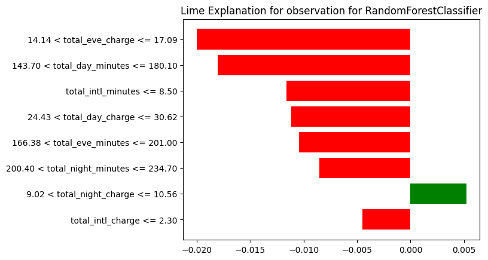

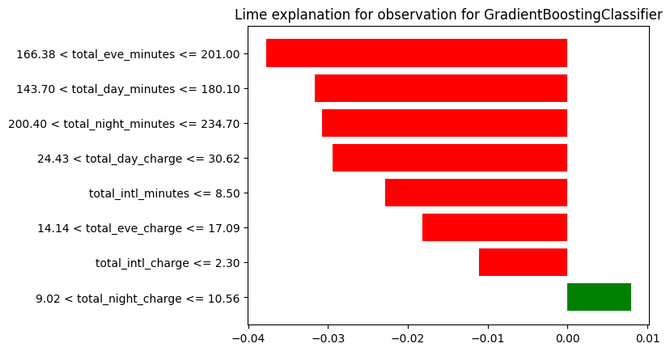

In some cases LIME explanations of 2 classifiers' predictions can be really similar where the biggest differences are results of models seemingly deeming one of 2 codependent variables more important than the other, here exemplified by swapping day charges and day minutes (duration of calls)

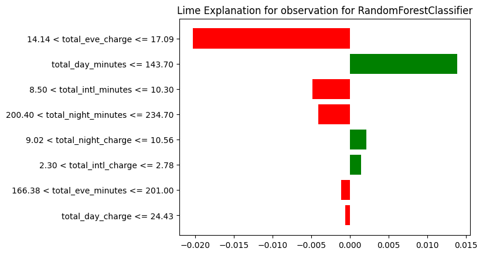

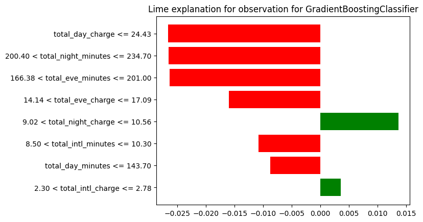

In other cases like this the explanations differ greatly.

It seems like the differences in explanations across models are mainly the result of differences in models themselves, placing more emphasis on particular features, especially when features are very strongly correlated in a dataset, like time spent talking and amount paid for that time so that the features convey the same thing for a simple model and their relative importance seems to be mainly chance.